# Árvore de Decisão - Introdução

Machine-learning

Tutorial

R

Autor

Afiliação

Gabriel Rodrigues, MSc

Universidade Estadual de Santa Cruz

Data de Publicação

11 de novembro de 2025

Resumo

Relatório formal de análise de dados da Disciplina “Ciência de Dados”, ministrada pelo Professor Eric Roberto Guimarãers Rocha Aguiar e tendo como aluno de Estágio em Docência Gabriel Victor Pina Rodrigues. O presente relatório foi criado utilizando a plataforma Quarto® com linguagem R.

Palavras-chave

Data-Science, Machine-Learning, Decision-Tree

# 1 Introdução

## 1.1 O que é Aprendizado de Máquina?

Em termos gerais, *Machine Learning* (ML) ou **Aprendizado de Máquina** é um subconjunto da Inteligência Artificial (IA) que permite que sistemas de computador aprendam e melhorem automaticamente a partir da experiência (dados), sem serem explicitamente programados para cada tarefa específica.

O emprego de métodos de Aprendizado de Máquina pode variar desde recomendações de filmes e músicas para usuários baseado em seu histórico de consumo, até na análise de imagens médicas para a detecção de doenças e diagnóstico.

## 1.2 Tipos de Aprendizado de Máquina

Existem diversas abordagens para o aprendizado, mas as duas categorias principais são:

- **Aprendizado Supervisionado** (Supervised Learning): O modelo é treinado usando dados rotulados. É como aprender com um professor que sempre fornece as respostas corretas. **Exemplo:** Treinar um modelo com imagens já marcadas como “SPAM” ou “NÃO SPAM” para que ele aprenda a filtrar novos e-mails.
- **Aprendizado Não Supervisionado** (Unsupervised Learning): O modelo é treinado usando dados não rotulados e tem que encontrar a estrutura, agrupamentos (clustering) e padrões por conta própria. É como agrupar itens por cor sem que ninguém diga o nome das cores. **Exemplo:** Agrupar clientes de e-commerce com base em seus hábitos de compra para segmentação de marketing.

# 2 Árvore de Decisão

Uma Árvore de Decisão (*Decision Tree*) é um algoritmo de aprendizado de máquina supervisionado usado tanto para tarefas de classificação quanto de regressão. Ela modela decisões sequenciais baseadas em características dos dados, de forma que se assemelha a uma estrutura de fluxograma.

## 2.1 Estrutura e funcionamento

O principal objetivo de uma Árvore de Decisão é criar um modelo que prevê o valor-alvo (o target) ao aprender regras de decisão simples inferidas das características dos dados (features).

- Nó Raiz (Root Node): É o ponto inicial, representa todo o conjunto de dados.
- Nós de Decisão Internos (Internal Decision Nodes): Representam testes em um atributo (característica) dos dados. A partir deles, o conjunto de dados é dividido em subconjuntos com base no resultado do teste. Por exemplo, “A idade é maior que 30?”
- Ramos (Branches/Edges): São as possíveis respostas ou caminhos resultantes do teste em um nó de decisão.
- Nós Folha (Leaf Nodes): Representam os resultados finais ou a decisão. Em um problema de classificação, a folha contém o rótulo da classe (ex: “aprovado” ou “negado”). Em um problema de regressão, contém um valor previsto (ex: a média dos valores daquele subconjunto).

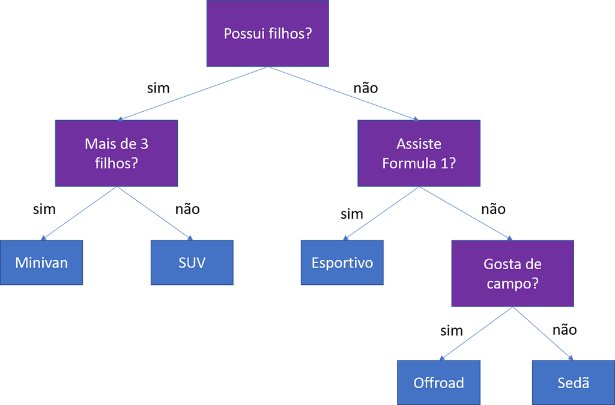

Exemplo de Árvore de Decisão

Nesse exemplo, a árvore de decisão se baseia em informações pessoais dos itens (das pessoas), para a partir delas prever o tipo de carro mais provável para compra.

# 3 Construindo Árvores de Decisão no R

Para criar uma árvore de decisão no R, deve-se utilizar o pacote `rpart`, ele é um pacote em R para construir árvores de decisão que podem ser usadas para classificação ou regressão. A função principal `rpart()` cria o modelo da árvore de decisão, e pacotes adicionais como `rpart.plo`t podem ser usados para visualização.

## 3.1 Bloco 1 - Instalando pacotes e importando dados

```r
# 1. Instale os pacotes (rode apenas uma vez)
# install.packages("rpart")
# install.packages("rpart.plot")

# 2. Carregue os pacotes
library(rpart)
library(rpart.plot)

# 3. Carregue o dataset "iris" (que já vem com o R)
# Vamos chamá-lo de "dados" para ficar mais claro
dados <- iris

# Dê uma olhada rápida nos dados
# Queremos prever "Species" usando as outras 4 colunas
head(dados)
```

```
  Sepal.Length Sepal.Width Petal.Length Petal.Width Species
1          5.1         3.5          1.4         0.2  setosa
2          4.9         3.0          1.4         0.2  setosa
3          4.7         3.2          1.3         0.2  setosa
4          4.6         3.1          1.5         0.2  setosa
5          5.0         3.6          1.4         0.2  setosa
6          5.4         3.9          1.7         0.4  setosa
```

## 3.2 Bloco 2 - Implementando o Modelo

```r
# Treina o modelo da árvore
# method = "class" informa ao rpart que é um problema de CLASSIFICAÇÃO
modelo_arvore <- rpart(
  Species ~ .,
  data = dados,
  method = "class"
)

# Para ver um resumo simples das regras em texto
print(modelo_arvore)
```

```
n= 150

node), split, n, loss, yval, (yprob)
      * denotes terminal node

1) root 150 100 setosa (0.33333333 0.33333333 0.33333333)
  2) Petal.Length< 2.45 50   0 setosa (1.00000000 0.00000000 0.00000000) *
  3) Petal.Length>=2.45 100  50 versicolor (0.00000000 0.50000000 0.50000000)
    6) Petal.Width< 1.75 54   5 versicolor (0.00000000 0.90740741 0.09259259) *
    7) Petal.Width>=1.75 46   1 virginica (0.00000000 0.02173913 0.97826087) *
```

## 3.3 Bloco 3 - Gerando Visualização

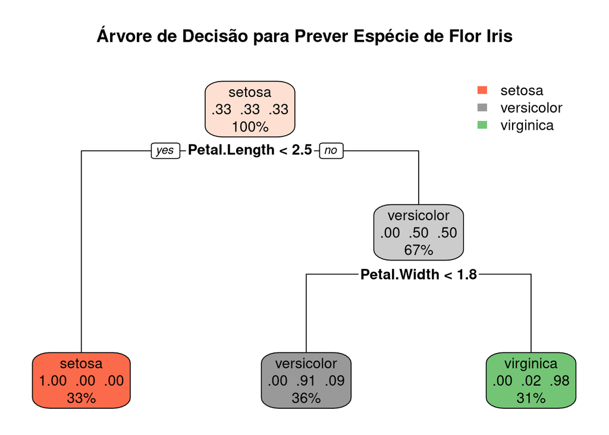

```r
# Criar a visualização da árvore
# Esta é a "saída" do algoritmo!
rpart.plot(modelo_arvore, main = "Árvore de Decisão para Prever Espécie de Flor Iris")
```

## 3.4 Bloco 4 - Classificando Novo Item

```r
# Vamos criar uma "nova flor" que medimos no jardim
# Ela tem pétalas longas e largas.
nova_flor <- data.frame(
  Sepal.Length = 5.1,
  Sepal.Width = 3.2,
  Petal.Length = 4.8,
  Petal.Width = 1.9
)

# Usar o modelo para prever a qual classe (espécie) ela pertence
previsao <- predict(modelo_arvore, nova_flor, type = "class")

# Mostrar o resultado
print(paste("A previsão do modelo para a nova flor é:", previsao))
```

```
[1] "A previsão do modelo para a nova flor é: virginica"
```

A partir da inserção do novo item, seguindo os mesmos parâmetros do dataset original, é possível classificar um novo item em uma das categorias estabelecidas.